# Analysis Section

First a bit of set up. The cleaned data set from the Gather-Assess-Clean section is imported and then the columns converted to their correct data type.

```python
import pandas as pd
import numpy as np
import time
import matplotlib.pyplot as plt
```

```python
#reimport the data
analysisDf = pd.read_csv('cleaned_data.csv', encoding='utf-8')
analysisDf.info()
```

```
<class 'pandas.core.frame.DataFrame'>
RangeIndex: 1982 entries, 0 to 1981
Data columns (total 10 columns):
tweet_id                 1982 non-null int64
timestamp                1982 non-null object
text                     1982 non-null object
rating_numerator         1982 non-null float64
rating_denominator       1982 non-null int64
name                     1982 non-null object
dog_age_stage            332 non-null object
favorite_count           1982 non-null int64
retweet_count            1982 non-null int64
most_likely_dog_breed    1432 non-null object
dtypes: float64(1), int64(4), object(5)
memory usage: 154.9+ KB
```

```python
#convert datatypes back to what they were before saving as a csv
analysisDf = analysisDf.astype({'timestamp': 'datetime64[ns]',
                                'dog_age_stage': 'category',
                                'most_likely_dog_breed': 'category'})
analysisDf.info()
```

```
<class 'pandas.core.frame.DataFrame'>
RangeIndex: 1982 entries, 0 to 1981
Data columns (total 10 columns):
tweet_id                 1982 non-null int64
timestamp                1982 non-null datetime64[ns]
text                     1982 non-null object
rating_numerator         1982 non-null float64
rating_denominator       1982 non-null int64
name                     1982 non-null object
dog_age_stage            332 non-null category
favorite_count           1982 non-null int64
retweet_count            1982 non-null int64
most_likely_dog_breed    1432 non-null category
dtypes: category(2), datetime64[ns](1), float64(1), int64(4), object(2)
memory usage: 134.1+ KB
```

## Insight #1: Average Rating

The first thing I want to look at is what is the average rating?

I'm normalising the values by diving by the denominator and then multiplying again by 10 to deal with the few values that have a very high numerator and high denominator.

```python
analysisDf['normRatings'] = ((analysisDf.rating_numerator / analysisDf.rating_denominator)*10)
```

```python
print('Mean:', analysisDf.normRatings.mean())
print('Median:', analysisDf.normRatings.median())
print('Mode:', analysisDf.normRatings.mode())
```

```
Mean: 12.06598385469223
Median: 11.0
Mode: 0    12.0
dtype: float64
```

The average value is 12/10 but interestingly the median is lower at 11/10. This suggests the distribution is skewed I'm interested to plot what it is.

## Visualisation #1: Normalised Ratings Distribution

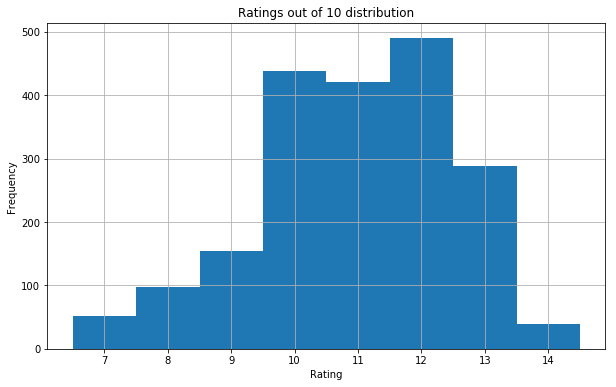

```python
plt.figure(figsize=(10, 6)) #set plot size, must do before calling .plot()

analysisDf.normRatings.hist(bins = 8, range=(7,15), align='left')

plt.title('Ratings out of 10 distribution')
plt.xlabel('Rating')
plt.ylabel('Frequency')
plt.show()
```

This shows a negatively skewed distribution.

As shown by the mode 12 is indeed the most common rating closely followed by 10 and then 11. There's a few lucky dogs who manage 14.

```python
(analysisDf.normRatings[analysisDf.normRatings>=14].count() / analysisDf.normRatings.count()) *100
```

```
2.0686175580221997
```

They really are lucky dogs. **Only 2.1% of dogs manage a rating of 14 or more!**

## Insight/Visualisation #2: Ratings over time

I'm interested to look at this as you hear a lot about grade inflation in the education system. Does the same apply to the world of social media based cute dog rating?

```python
meanRatingsWithTime = analysisDf.normRatings.groupby([analysisDf.timestamp.dt.year, analysisDf.timestamp.dt.month]).mean()
```

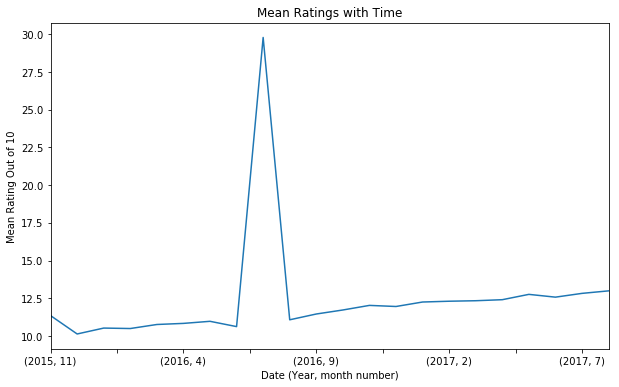

```python
plt.figure(figsize=(10, 6)) #set plot size, must do before calling .plot()

meanRatingsWithTime.plot()

plt.xlabel('Date (Year, month number)')
plt.ylabel('Mean Rating Out of 10')
plt.title('Mean Ratings with Time')
plt.show()
```

Whoa! What's going on in mid-ish 2016!

But also **Whoa! Ratings are definetly increasing with time!** No one is immue from grade inflation it seems, not even revered dog raters.

```python
meanRatingsWithTime
```

```
timestamp  timestamp
2015       11           11.359684
           12           10.143631
2016       1            10.534483
           2            10.504425
           3            10.771654
           4            10.844828
           5            10.982759
           6            10.632184
           7            29.787234
           8            11.083333
           9            11.466716
           10           11.732639
           11           12.037037
           12           11.964286
2017       1            12.260870
           2            12.313433
           3            12.346154
           4            12.414634
           5            12.767442
           6            12.583333
           7            12.833333
           8            13.000000
Name: normRatings, dtype: float64
```

Look at those figures! The mean rating per month has increased from roughly 10.5/10 at the start of 2016 to an increadible 13/10 by August 2017.

I'm going to take a look at what's causing the outlier in July 2016.

```python
analysisDf[(analysisDf.timestamp >= '2016-07') & (analysisDf.timestamp < '2016-08')].rating_numerator.value_counts()
```

```
11.0      27
10.0      22
12.0      21
13.0      12
8.0        5
9.0        3
1776.0     1
14.0       1
165.0      1
7.0        1
Name: rating_numerator, dtype: int64
```

```python
analysisDf[analysisDf.rating_numerator == 1776].text.iloc[0]
```

```
"This is Atticus. He's quite simply America af. 1776/10 https://t.co/GRXwMxLBkh"
```

The high value was for a very high rating of 1776/10 given to one dog that is skewing the mean. I could remove that value but don't want to seeing as it's a real rating.

One way to avoid this skewing in the plot would be to take the median instead of the mean. This will be less skewed by high values.

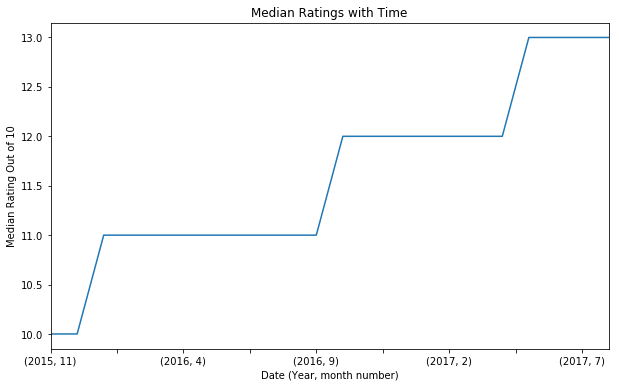

```python
medianRatingsWithTime = analysisDf.normRatings.groupby([analysisDf.timestamp.dt.year, analysisDf.timestamp.dt.month]).median()

plt.figure(figsize=(10, 6))
medianRatingsWithTime.plot()
plt.title('Median Ratings with Time')
plt.xlabel('Date (Year, month number)')
plt.ylabel('Median Rating Out of 10')
plt.show()
```

This makes the increase with time even clearer. It's now also blockier as median value each month is a whole number.

You can really see the walk from 10 to 13.

## Insight / Visualisation #3: Most Common Dog Breeds

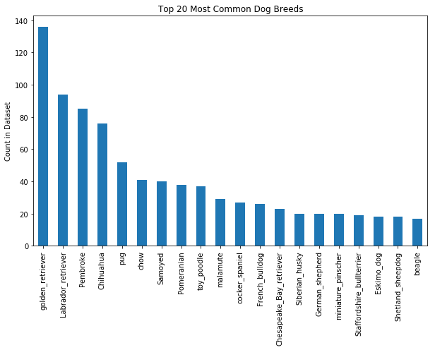

```python
plt.figure(figsize=(10, 6))

analysisDf.most_likely_dog_breed.value_counts()[0:20].plot(kind='bar')

plt.title('Top 20 Most Common Dog Breeds')
plt.ylabel('Count in Dataset')
plt.show()
```

Golden retrievers are by far the most common dogs featured on WeRateDogs. So if you do have one and want to submit pictures you stand the best chance of being rated!

# Wrap Up

There's a lot more that could be anaylsed here but unfortunately I'm under time pressure and I believe what's I've done more than meets the project requirements.

I've enjoyed using Pandas a lot in this project to analyse, subset and merge the different datasets. I've used Pandas a lot before but never really felt like I "got it" so this has been really good practice.

I also liked using regular expressions. I did know about them before this course but never really got when they'd be used. Now I understand why they're so useful!

Finally making some plots was good practice. The first part of this course was on R and making plots in it so I'm glad for the oppertunity to practice plotting in Python too to refresh my memory.